# Práctica de ruido

## 1. INTRODUCCIÓN TEÓRICA

Experimentalmente se comprueba que las variaciones de sensación sonora no son proporcionales a las variaciones de intensidad del sonido que llega al oído. Es decir, si al oído llegan dos estímulos tales que uno es el doble que el otro, las dos sensaciones que inducen no guardan la misma proporción entre ellas. De hecho, el estímulo ($E$) y la sensación ($S$) están relacionados por la llamada ley de Weber-Fechner, que se expresa por la ecuación:

$$S=k \cdot log E$$

Derivando esta ecuación se comprueba que las variaciones de sensaciones son proporcionales a los incrementos relativos ($dE$) de los estímulos:

$$dS=k \frac{dE}{E}$$

Por eso, en acústica se utiliza una escala de intensidades relativas, utilizando como unidad el Belio, que se define como el incremento que corresponde a una relación de intensidades de 1:10, es decir:

$$1 Belio = log\frac{10 I_i}{I_i}$$

Lo que implica que el número de Belios, correspondiente a una relación de intensidades $I_2/I_1$, se determina mediante la expresión:

$$n^o de Belios = log\frac{I_2}{I_1}$$

En consecuencia, se define una escala logarítmica que relaciona intensidades relativas.

Entonces, eligiendo una intensidad de referencia $I_0$ = 10$^{-12}$ W$\cdot$m$^{-2}$ (que aproximadamente corresponde al umbral de percepción de un sonido de frecuencia 1000 Hz) se obtiene una escala absoluta de intensidades dada por:

$$L_i = log\frac{I_i}{I_0}$$

Así, los valores extremos son:

Máximo ($M$):
$$L_M = log\frac{I_M}{I_0}=log \frac{100 \; W \cdot m^{-2}}{10^{-12}\; W \cdot m^{-2}}=14 \; Belios$$

Mínimo ($m$):
$$L_m = log\frac{I_0}{I_0}=log \; 1=0 \; Belios$$

De esta manera se obtiene una escala de niveles de intensidad acústica comprendido entre 0 y 14 Belios, que es un intervalo menor que si se utilizara una escala en W$\cdot$m$^{-2}$ (de $10^{-12}$ a $10^2$).

Como el Belio es una unidad demasiado grande para las intensidades acústicas normales, la unidad que se utiliza de forma general es el decibelio (dB) que es la décima parte del Belio. En consecuencia, el nivel absoluto de una intensidad $I_i$ expresado en dB será:

$$L_i = 10 \cdot log\frac{I_i}{I_0}$$

La expresión del nivel de intensidad puede adoptar distintas formas en función de los parámetros que intervienen en su medida. Así, se puede expresar en función de la potencia de la fuente ($W$), de la distancia ($r$) o de la presi'on ($p$), de forma que:

$$L_i = 10 \cdot log\frac{I_i}{I_0}=10 \cdot log \frac{W_i / 4 \pi r^2}{W_0 / 4 \pi r^2} =
10 \cdot log \frac{W_i}{W_0}=10 \cdot log \frac{p_i^2/ \rho c}{p^2_0 / \rho c} =
20 \cdot \frac{p_i}{p_0}$$

## 2. Operaciones con niveles acústicos en decibelios

Como la unidad dB tiene un carácter logarítmico, para operar con magnitudes que están expresadas en dB hay que observar ciertas precauciones, relacionadas con las operaciones logarítmicas.

La intensidad sonora $I_t$ resultado de varias fuentes $I_i$ se puede calcular directamente mediante $I_t=\sum I_i$. Teniendo en cuenta que la definici'on de los logaritmos dice que $a=log\; b \Leftrightarrow 10^a=b$, podemos expresar la relaci'on $L_i \Leftrightarrow I_i$ como:

$$L_i = 10 \cdot log\frac{I_i}{I_0} \Leftrightarrow \frac{L_i}{10}= log\frac{I_i}{I_0}
\Leftrightarrow 10^{\frac{L_i}{10}}=\frac{I_i}{I_0}$$

Al pasar a la escala logarítmica, se obtiene lo siguiente:

$$L_t= 10 \cdot log\frac{I_t}{I_0}=10 \cdot log \frac{\sum{I_i}}{I_0} =
10 \cdot log \sum(\frac{I_i}{I_0})= 10 \cdot log \sum 10^\frac{L_i}{10}$$

Por ejemplo, el nivel de intensidad o presi'on ac'ustica de tres señales de 40, 50 y 60 dB resulta:

$$L_t=10 \cdot log(10^4+10^5+10^6) = 60.45 dB$$

Esto supone que el resultado de la suma de varias fuentes sonoras es un nivel acústico muy próximo al de la fuente más intensa.

**Pregunta**: ¿Podrías calcular en R el anterior ejemplo? Escribe el código a continuación

El objetivo de la práctica es calcular el nivel de ruido equivalente para cada día de la semana.

## 3. Índices acústicos

El objetivo de estos índices es valorar de forma cuantitativa la posible molestia que provocan los ruidos ambientales de muy diversa procedencia, y por tanto de intensidades y frecuencias muy variables.

Cuando se consideran niveles que varín temporalmente $L(t)$, como sería por ejemplo el ruido de tráfico rodado, se utiliza el llamado nivel continuo equivalente ($L_{eq}$), que se define como el nivel en $dB$ correspondiente al promedio de la cantidad de energía acústica variable durante un periodo de tiempo $T$, cuya ecuación matemática es:

$$L_{eq}=10 \cdot log [ \frac{1}{T} \int_0^T 10^\frac{L(t)}{10} dt ]$$

que se puede calcular de forma aproximada mediante la expresión:

$$L_{eq}=10 \cdot log [ \frac{1}{T} \sum \left(t_i \cdot 10^\frac{L_i}{10} \right)]$$

siendo $t_i$ los tiempos de observación durante los cuales el nivel sonoro $L_i$ se mantiene en un intervalo de $\pm$ 2 $dB$.

¿Cuál es el nivel continuo equivalente correspondiente al ruido de tráfico observado a lo largo de un día en una determinada calle urbana con la siguiente distribución de niveles sonoros: 85 dB durante 4 horas, 90 dB durante 2 horas, 80 dB durante 10 horas y 65 dB durante 8 horas?

Solución:

$$L=10 \cdot log(\frac{4 \cdot 10^{8.5}+2 \cdot 10^9+ 10 \cdot 10^8 + 8 \cdot 10^{6.5}}{24})=82.52 dB$$

Este criterio se establece a causa de la necesidad de evaluar de diferente formalos niveles de ruido urbano durante el día, la tarde y la la noche, penalizando los ruidos nocturnos por estimar que la molestia que producen es mayor. Su valor se calcula con la ecuación:

$$L_{den}=10 \cdot log[\frac{12 \cdot 10^{L_d/10}+ 4 \cdot 10^{(L_e+5)/10} + 8 \cdot 10^{(L_n+10)/10}}{24}]$$

donde $L_d$ representa el nivel sonoro equivalente para el periodo de día, $L_e$ para el periodo de tarde y $L_n$ para el periodo nocturno.

**Para saber exactamente los periodos correspondientes a cada tramo horario, consulta la ordenanza municipal de Toledo, por ejemplo, en su artículo 55.3, o en el Anexo I.A.1.**

Es un '{}ndice obtenido de la combinaci'on ponderada de $L_{10}$ y $L_{90}$, promediadas a lo largo de un periodo de tiempo de 24 horas, de manera que:

$$TNI=4(L_{10}-L_{90})+L_{90}-30$$

Cálculo de los diversos índices de ruido urbano correspondientes a una serie de medidas de niveles acústicos registrados en la Plaza de Cuba de la ciudad de Toledo. Los valores que se muestran en las tablas proporcionadas corresponden a promedios diezminutales (en dB) a lo largo de una semana.

En un documento word responde a las siguientes cuestiones:

- Calcula los siguientes índices para cada día de la semana :
- Nivel continuo equivalente ($L_{eq}$)
- Nivel día-tarde-noche ($L_{den}$) junto con los niveles de día ($L_d$), de tarde ($L_e$) y de noche ($L_n$)
- El índice de ruido de tráfico ($TNI$) (además de los percentiles), y anota los resultados en una tabla.
- Comenta estos resultados. Especula sobre las diferencias entre los diferentes valores obtenidos para estos índices, y la posible explicación sobre su evolución a lo largo de la semana. Representa las series temporales directas por si te sirve de ayuda.

# 4. Desarrollo de la práctica

### 1. Cargo las librerías necesarias y leo los datos.

```r
lunes <- read.csv("data/lun_cuba_10min.csv", dec=',')
```

Observo el objeto creado *lunes*

```r
head(lunes)
```

|  | X | X.1 |
| --- | --- | --- |
| 1 | 00:00:00 | 63.32 |
| 2 | 00:10:00 | 61.22 |
| 3 | 00:20:00 | 62.62 |
| 4 | 00:30:00 | 67.52 |
| 5 | 00:40:00 | 58.06 |
| 6 | 00:50:00 | 56.30 |

**Pregunta:**

- ¿Qué significa el comando ‘head’?
- ¿Qué clase de objeto es *lunes*?

### 2. Asigno los nombres a las columnas del ‘data.frame’.

```r
colnames(lunes) <- c("time", "intensidad")
```

### 3. Represento los datos:

Utilizo la función base plot de R:

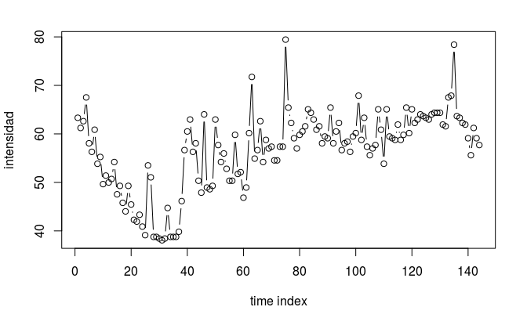

```r
plot(lunes[1:144,2], type='b', ylab='intensidad', xlab='time index')
```

Como es una serie temporal, también puedo utilizar las funciones ts:

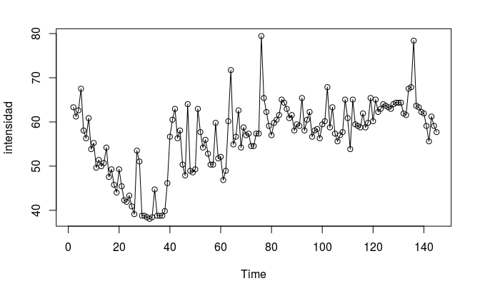

```r
ts.plot(lunes[2], type='o', ylab='intensidad')
```

La función ts.plot considera el que el argumento que se le introduce es una series temporal y lo representa como tal. Esta función acepta como argumentos ‘type’ para cambiar el tipo de representación y distintos argumentos para insertar el título y el nombre en los ejes.

**Pregunta: Haz diferentes pruebas del tipo de gráfica. Cambia colores o maneras de representar.**

### 4. Cálculo de índices de ruido

**Nivel de ruido equivalente diario**: *Leqdiario*

Para calcular Leq introduciré los valores de la expresión según los datos de ‘lunes’.

1. Introduzco el término exponencial:

```r
t1<-10^(lunes[2]/10)
```

2. Lo multiplico por 10

```r
deltat<-10.
```

3. Hago el sumatorio:

```r
t2<-sum(deltat*t1, na.rm=TRUE)
```

4. Calculo el logaritmo en base 10 y multiplico

```r
leqlunes<-10*log10(1/(60*24)*t2)
```

- Leq diurno: 43 a 114, de 7 a 19h: 12h
- Leq tarde: 115 a 138: 19 a 23: 4 h
- Leq nocturno: 1 a 42 y 139 a 144: 0 a 7 y 23 a 24: 8h

Cálculo del Leq diurno

```r
t1d<-10^(lunes[43:114,2]/10)
t2d<-sum(deltat*t1d, na.rm=TRUE)
leqdlunes<-10*log10(1/(60*12)*t2d)
```

Cálculo del Leq de la tarde

```r
t1t<-10^(lunes[115:138,2]/10)
t2t<-sum(deltat*t1t, na.rm=TRUE)
leqtlunes<-10*log10(1/(60*4)*t2t)
```

Cálculo del Leq nocturno

```r
t1n1<-10^(lunes[1:42,2]/10)
t1n2<-10^(lunes[139:144,2]/10)
t2n<-sum(deltat*t1n1, na.rm=TRUE)+sum(deltat*t1n2, na.rm=TRUE)
leqnlunes<-10*log10(1/(60*8)*t2n)
```

Cállculo del ruido equivalente total:

```r
ttd=10^(leqdlunes/10)
ttt=10^((leqtlunes+5)/10)
ttn=10^((leqnlunes+10)/10)
ldn=10*log10((12*ttd+4*ttt+8*ttn)/24)
```

## 5. Cálculo de los percentiles:

```r
rlunesp90<-quantile(rlun[,2],0.9)
rlunesp10<-quantile(rlun[,2],0.1)
tni<-4*(rlunesp90-rlunesp10)+rlunesp10-30
```